# Exploratory Analysis of US Flight Data (2008)

## Overview of Data Set

The data set is an annual report of all flights originating or terminating within the United States provided by the Bureau of Transportation Statistics. The data set meticulously details all aspects of each flight log and in the year 2008 (which will be the initial focus of the EDA) includes over 7 million observations. The data file used for this analysis was downloaded from American Statistical Association website where the full data set is divided into smaller files by year.

The data includes 29 variables for each observation, although with numerous missing values. The 2008 data set, the most recent available on the ASA site, was chosen because it had more complete data coverage and fewer missing values than some earlier data sets previewed.

Because the file includes all flights for the given year, it could be argued that we are dealing with data for the full target ‘population’. This would be the case if we were limiting our inquiry to 2008. Instead, though, we’re going to take the data set for that particular year as the sample, ignoring for the time being any historical effects that might confound the generalizability of our fingings to data from other years.

Due to the size of the data set and to expedite analysis, we’re going to take a random sample of the full set, working with just one-tenth of the observations. Not only will this make analysis more efficient but also give us the opportunity to test some of our results against the full data set.

## Guiding Questions

The questions that would guide our exploration of this data set depends foremost on who’s interested in the final analysis. Decision makers at airlines, air travel safety officials, and frequent fliers would likely all find different variables of interest. To narrow the scope and sharpen the focus of our analysis we’ll focus on the data from the passenger’s point of view. Passengers are usually most directly effected and therefore concerned with delays and cancellations. Based on this fact we will proceed with the EDA guided by the following general question: *What variables are associated with departure delays?*

As we progress with the EDA, we’ll articulate and address other questions that arise. Ideally, our observations and analyses with lead to insights that can inform the travel-savvy airline passenger. Let’s jump into the data by looking at variables that intuitively we’d suspect are associated with departure delays.

## Univariate/Multivariate Analysis & Plots

The volume of flights, well over 7 million, for one year is almost hard to iamgine, but at the same time provides a robust data source for reliable and accurate analysis even while using a random sample of only 10%. While there are 29 variables describing each flight, many of which are simply boolean dummy-variables for marking reasons for delays and cancelations and may not be relevant to our exploration.

As customers interested in either minimizing delays and cancellations or avoiding the headache of being stranded at an airport because we inadvertantly found ourselves in just conditions for a delay. Some of the factors that standout as worth investigating include:

- time-stamp variables (year, month, day, hour) - intuitively when we fly seems like a strong candidate contributor to delays. Anecdotely, holiday flights are notorious for delays. How does this play out statistically, though. *Are there months, days, or times of day that are more associated with delays or cancellations?*
- carrier - some airlines are well-known for their reliability while others for the opposite. *Is there a significant association between airline carrier and delays and cancellations?*
- origin/destination - a multitude of factors are involved here; airport design and age, climate, the number of runways among others make this a variable of interest. *Are there airports that are more reliably on-time all else being equal, and conversely, are there airports that are strongly associated with dealys all else being equal?*
- distance - intuitively we’d think that a longer flight has more opportunities to be delayed. *Are the diatance of a flight and delays and cancellations associated?*

Along with these variable will also rely heavily on the binary, categorical, and continuous variables that respectively encode whether a flight was delayed or cancelled, for what reason, and by how long.

Let’s start by looking at what will eventually serve as our primary dependent variable as we look around for correlations, departure delays.

#### **Variable:**

`DepDelay` - Departure delay in minutes, continuous numerical variable.

#### **Intuition/Motivation:**

The departure delay variable is the difference between the scheduled and actual departure times measured in minutes. My sense would be that departure delays are normally distributed around a mean some where around 45 minutes to an hour. I would also imagine that there would be a cut off or upper limit for delay times past which the flight would be reclassified as cancelled. First let’s glance at the distribution of delay times.

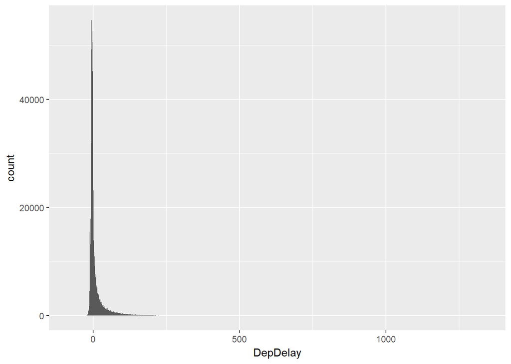

```
## Number of 0 values in `DepDelay` =  NA
```

```
##
## Number of NA values in `DepDelay` =  13632
```

Next, let’s address the extreme values, both the postive outliers that exaggerated the scale of our first plot and the abundant negative departure delays that skew the bulk of the distribution density into a negative range. We’ll use a table get a better look at these extremes.

```
## delay_times
##   -79   -71   -67   -64   -61   -58   -56   -54   -49   -45   -44   -40
##     1     1     1     1     1     1     1     1     1     2     1     3
##   -38   -36   -34   -32   -31   -30   -29   -28   -27   -26   -25   -24
##     3     1     2     2     4     6     6     8    11     6    28    18
##   -23   -22   -21   -20   -19   -18   -17   -16   -15   -14   -13   -12
##    28    42    48   117   120   194   228   415   881  1089  1784  2948
##   -11   -10    -9    -8    -7    -6    -5    -4    -3    -2    -1   605
##  4541 15484 13223 17916 24696 31907 54613 49198 50564 48906 45148     1
##   610   611   612   619   620   629   632   645   653   658   659   660
##     1     2     1     1     1     2     1     2     1     2     2     1
##   663   669   671   680   682   683   703   708   711   716   729   731
##     1     1     2     1     1     1     2     1     1     1     1     1
##   735   738   744   745   749   757   758   774   785   798   806   813
##     1     1     1     1     1     1     1     1     3     1     1     1
##   814   816   824   826   852   854   877   907   910   918   945   953
##     1     1     1     1     1     1     1     1     2     1     1     1
##   974   979   990   996  1000  1011  1014  1021  1030  1078  1126  1134
##     1     1     1     1     1     1     1     1     1     1     1     1
##  1153  1179  1240  1250  1337
##     2     1     1     1     1
```

The negative delay values (i.e. >-20) suggest one half of a normal or exponential distribution. Let’s quickly plot the values between -20 and 20 to see.

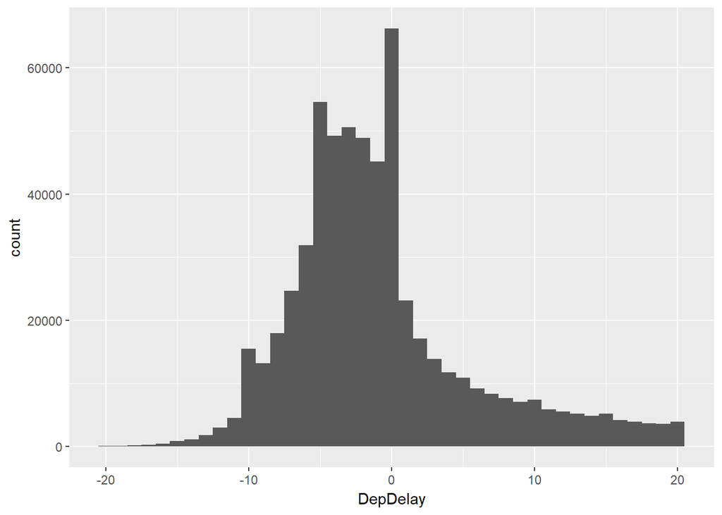

Considering everything and everyone involved in getting a flight off the ground, it would be unreasonable to define an on-time flight as coinciding exactly with a schedule. We’ll define, instead, a symmetric range around zero of delays that we’ll count as on-time. Assuming that a delay of fifteen minutes does not jeopordize flight connections or vacation itineraries, we’ll define a flight departure as on-time if: -15<DepDelay<15.

Now let’s address the other values from the earlier table. Regarding the negative delay times, some of the lower values may be attributable to flights where all passengers were on board before the scheduled departure time. But the more extreme values warrent further investigation. Let’s look at the full record for the observations with the most extreme negative values.

```
##        UniqueCarrier Year Month DayofMonth DayOfWeek DepTime CRSDepTime
## 86844             AQ 2008     2         28         4     924       1025
## 95261             AS 2008     2          9         6    1645       1804
## 389762            OO 2008     3          2         7     838        945
## 668025            XE 2008     5         21         3    2144       2255
## 679629            YV 2008     8          4         1    1132       1236
##        ArrTime CRSArrTime FlightNum TailNum ActualElapsedTime
## 86844     1010       1108       216  N836AL                46
## 95261     2005       2058        64  N794AS               140
## 389762     921        925      2635  N496CA               103
## 668025    2233       2349      3040  N24517                49
## 679629    1349       1353      7151  N651ML               137
##        CRSElapsedTime AirTime ArrDelay DepDelay Origin Dest Distance
## 86844              43      28      -58      -61    HNL  KOA      163
## 95261             114     106      -53      -79    KTN  SEA      680
```

[output cut: 21 more lines]

A couple of the flights look particularly short in duration suggesting a regional flight where punctuality might not be paramount. Investigating the Bureau of Transportation Statistics website, it appears the departure delay is calculated as the difference between the actual departure time and a scheduled departure time submitted before hand by the airlines, just as we had first defined it. This system might not take into account rescheduling close to departure time, perhaps explaining the extreme negative values. At any rate, we’ll remove negative values less than -15 from the variable to clean the data up and facilitate analysis. This will only eliminate a small proprotion of the data.

Regarding the extreme positive delays, some of the values are beyond what would reasonably be considered a delay instead of a cancellation. The most extreme value is actually close to a full 24hr day. At the same time the frequency of long delays (i.e. >600 mins) is low, usually at or near a single observation. We’ll count these as outliers and define an upper limit to the variable, 15<DepDelay<480.

Let’s take a look at our revised distribution.

```
##    Min. 1st Qu.  Median    Mean 3rd Qu.    Max.
##   15.00   23.00   39.00   57.91   72.00  480.00
```

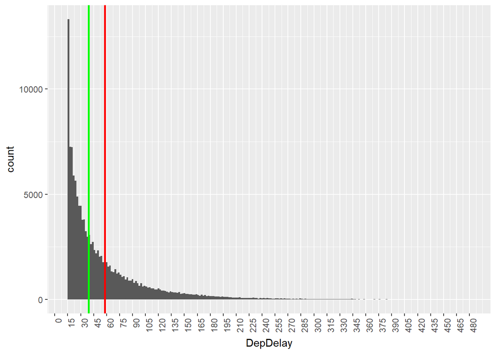

The distribution is exponential with exp<1.The red line represents the mean, the green the median. There are high frequencies of short delays decreasing in the right skewed distribution and trialing off with isolated delays of three or more hours. The mean and the median don’t coincide in this case which isn’t surprising with the pronounced right skew. The mean (~57mins) is appreciable in as much as it could imply a late arrival, a missed schedule or a foiled travel itinerary.

Clarifying our definition of delay in this way raises several issues. In the plot above, for example, the on-time values are left out. If they were included both the mean and the median would be near 0. The naive assumption earlier was that `DepDelay` was a normally distributed continuous variable of values between 1 and some reasonable ceiling. Such a model would have greatly simplified our attempts to determine association. But since it isn’t the case, we’ll need to modify the data to meet our new definition.

One possibility would be to modify `DepDelay`, eliminate a considerable proportion of the data and focus solely on observations with a delay. But instead and at least initially, we’ll create a new binary categorical variable `Delay` where any delay value falling within our defined delay range will have a value of 1. Any delays outside that range (or 0 values) will be assigned a 0. This will imply our working with proportions.

```
## Proportion of data remaining after elimination of outliers:
##  0.9979001
```

Even after removing the outliers we came away with well over 99% of the original data subset. Let’s see how the proportion of flights with delays and without divides up.

```
## Proportion of flights with departure delays:
##  0.1820801
```

The proportion of flights that were delayed is surprising low. Perhaps more credit is due the airlines and the airline industry as a whole.

Now that we have a better handle on this variable and we’ve created our categorical response variable, let’s take a closer look at some of the variables that might explain the variation in departure delays.

Let’s start by addressing a group of obvious covariates of `Delay` and `DepDelay`, namely the five continuous numeric variables that divide the overall delay variables into subcategories based on the cause(s) of the delay.

#### **Variables:**

`CarrierDelay`, `WeatherDelay`, `NASDelay`, `SecurityDelay`, `LateAircraftDelay`

#### **Intuition/Motivation:**

All of these variables measure in minutes their respective delay factor’s contribution to overall delay. All of these variable will not be especially useful in our predictive model since they are covariates of the dependent variable we’ve already selected. Still, it’s worth taking a look at how the distribution of the delay types to inform the selction of explanatory variables in our model.

Flights that had any delay for any reason have all delay columns filled albeit with zero values. Flights that were on time have NA’s

```
##      CarrierDelay      WeatherDelay          NASDelay     SecurityDelay
##             66714             10180             93323               623
## LateAircraftDelay
##             70069
```

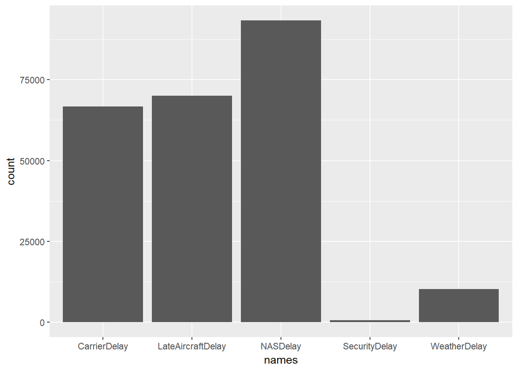

Let’s plot this data again so we can get an overall sense of the data proportionately.

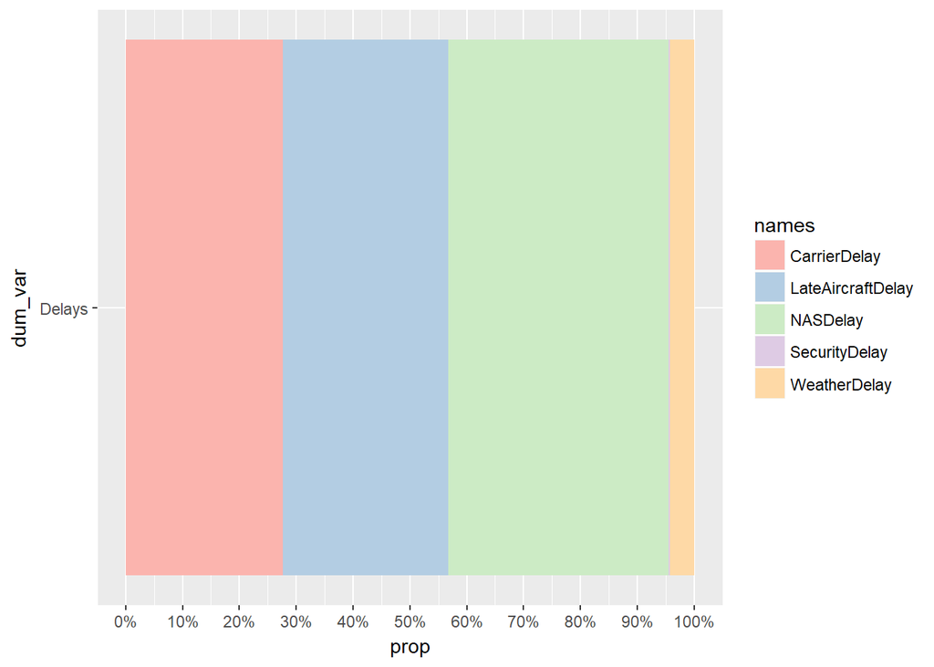

#### **Summary/Analysis:**

The graph serves the purpose that a pie chart would by showing proportional data in a graphically accurate way, and it gives us some useful clues for answering our guiding questions and will be useful later when we group this same data by flight origin and destination.

A remarkably small proportion of the flights are due to weather, even though these delays are the ones that are most prominant in media. It’s likely that even the relatively small proportion of weather delays is under-represented because weather events cause especially widespread flight complications by seeding delays caused by late arrivals. `WeatherDelay` and `LateAircraftDelay` are likely closely related.

Interestingly, this plot confirms our intuition about carriers being responsible for the delays. Depending on how you group the categories in the plot, carriers may be responsible for as much as 55% of delays. More conservatively, we could only place the blame for between a quarter and a third of delays.

Let’s look quickly at the five variables plotted together in another format.

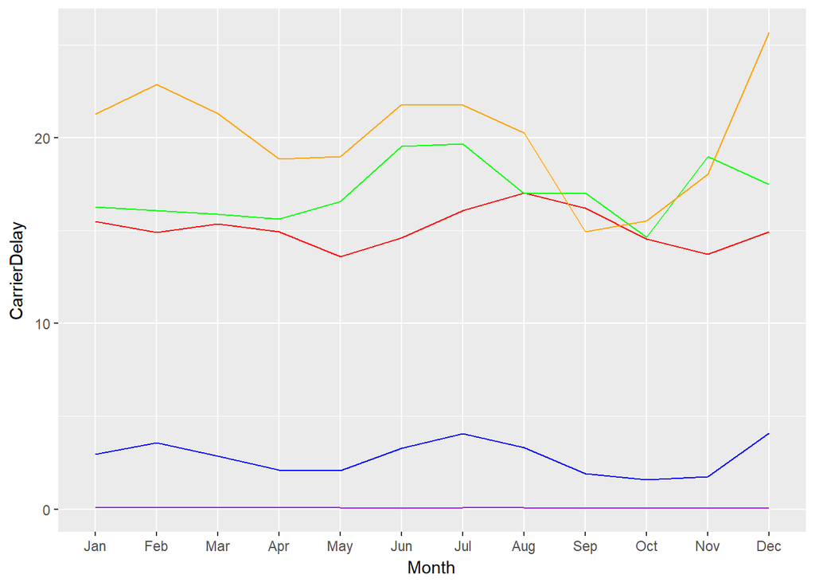

#### **Summary/Analysis:**

Where earlier we looked at counts and proportions of delays, here we’ve plotted the actual delay contribution in minutes for each delay type by month. Interestingly, The delays that are more frequent over all are on average also longer. The graph also shows an interesting multimodal distribution. This points to a seasonal influence on the length of delay even when accounting for delay type.

The first explanatory variable that stands out as a likely contributing factor to delays would be the time of year. We often hear of the holidays and the peak travel seasons of midsummer and late December as the most notorious for delays, an assumption that is often reinforced by news stories showing travelers stranded by delays and cancellations. We’ll also posit as our starting hypothesis that if there is an association between season and delay frequency it is by extension associated with increased flight volume during peak travel seasons. Of course, our task is to go beyond anecdotely evidence and find statistical evidence within the data.

We’ll start with the variable marking the month of each observation.

#### **Variable:**

`Month`

#### **Intuition/Motivation:**

We’ll look at the volume of flights by month to see both if month is a predictor of delays and if the sheer volume of flights is itself a contributor. Based on what we know about our own individual patterns of flying certain times of year almost certainly see significantly higher flight volumes.

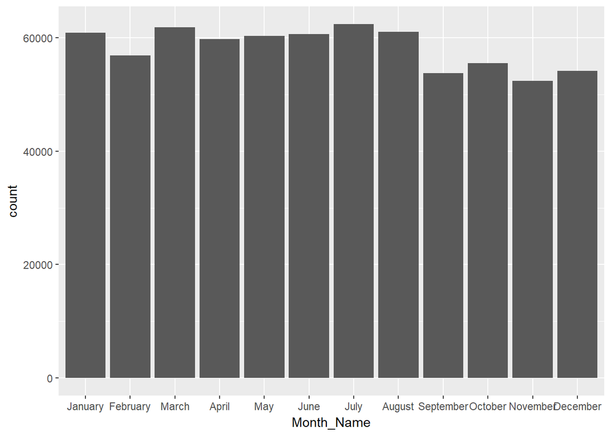

#### **Summary/Analysis:**

The bar plot doesn’t show the kind of variation that we’d expected. Although the summer months show a higher volume of flights, the holiday months of November and December actually show slightly lower volumes, although within month variation may be closer to our intuited distribution (we’ll look at this later). On the whole, the distribution even suggests that the volume of flights might not be the key factor behind perceived seasonal delays.

To be sure let’s look closer at the statistics related to this variable.

```
## # A tibble: 12 x 3
##    Month_Name count prop_of_total
##         <chr> <int>         <dbl>
##  1      April 59755    0.08542530
##  2     August 61019    0.08723231
##  3   December 54127    0.07737956
##  4   February 56910    0.08135811
##  5    January 60843    0.08698070
##  6       July 62394    0.08919800
##  7       June 60614    0.08665332
##  8      March 61877    0.08845890
##  9        May 60296    0.08619871
## 10   November 52397    0.07490636
## 11    October 55528    0.07938242
## 12  September 53740    0.07682630
```

```
##    Min. 1st Qu.  Median    Mean 3rd Qu.    Max.
##   52397   55178   60026   58292   60887   62394
```

```
## Standard deviation =  3536.04
```

Taking the standard deviation of 3536.04 for flight volume across months, let’s look at whether the flight volumes are significantly off the mean.

[figure not shown]

#### **Summary/Analysis:**

Although flight volume doesn’t appear to be the cause behind perceived seasonal delays, are delays more common during vacation and holiday months? Let’s control for differences in flight volume by looking at proportion of total flights delayed.

```
## # A tibble: 12 x 2
##    Month_Name    d_prop
##         <chr>     <dbl>
##  1      April 0.1651912
##  2     August 0.1723398
##  3   December 0.2660040
##  4   February 0.2289580
##  5    January 0.2041155
##  6       July 0.1944257
##  7       June 0.2241726
##  8      March 0.2166233
##  9        May 0.1581863
## 10   November 0.1260187
## 11    October 0.1085038
## 12  September 0.1087086
```

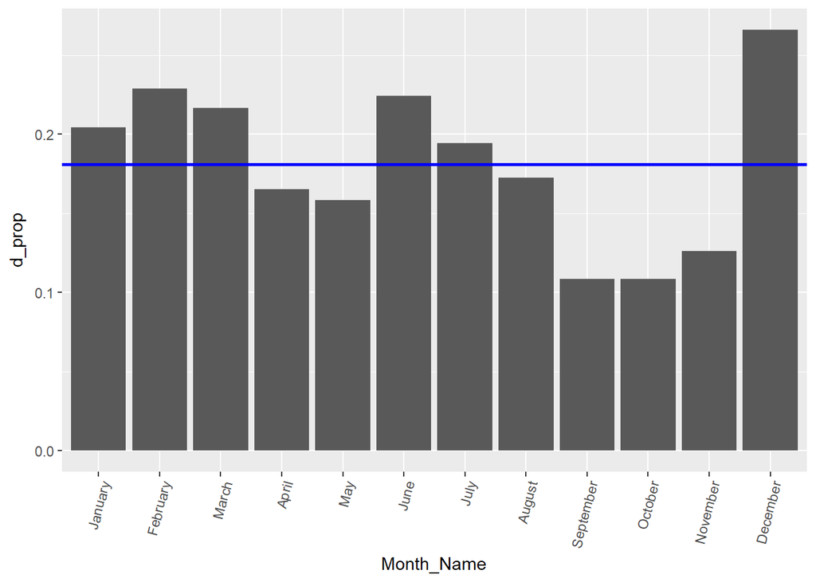

#### **Summary/Analysis:**

Where our initial focus on flight volume by month as the cause of delays failed to support an association between the variables of `Month` and `DepDelay`, the above plot seems to lend strong support to an association between `Month` and measures of delay. December and January, along with the summer months of June and July show higher than average flight delay proportions. But the plot may misrepresent the data to a small degree due to the narrow scale of the y-axis scale. To be sure the comparative differences aren’t exaggerated let’s correct the graph by adding standard deviation lines and then work with inferential tools to confirm that the difference is significant.

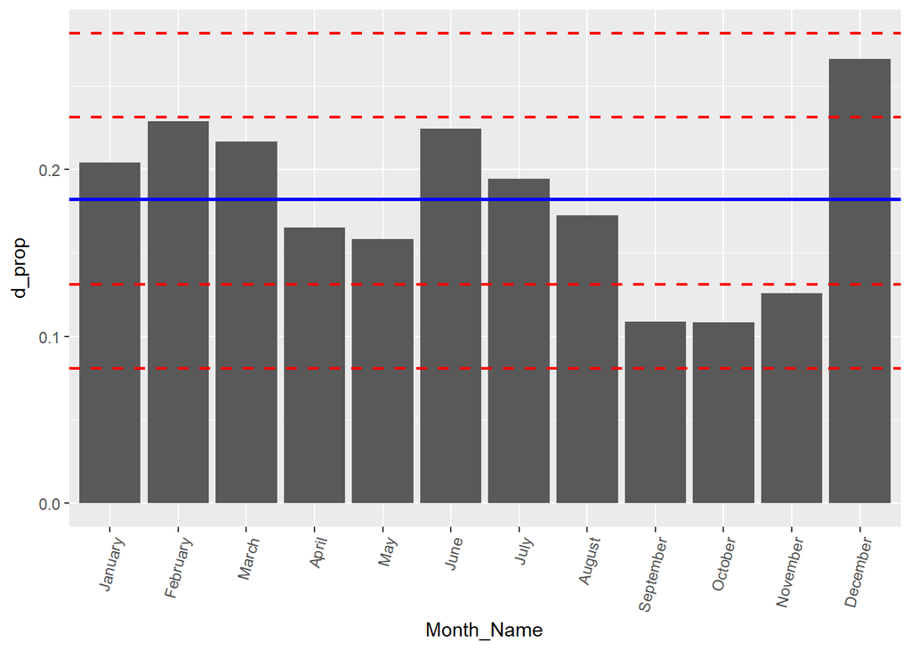

This difference in proportion of delays still looks appreciable. Let’s add statistical analysis to the plot to strengthen the argument that delays are associated with months.

We’ll work with ch-square goodness-of-fit test to detect any statistically significant difference between any two of the months. We’ll use the assume the uniform distribution with the mean monthly proportion as the expected distribution.

```
## Chi-squared: 0.02772307
```

```
##
## p-value: 2.068473e-13
```

With a p-value well below our critical value of alpha=0.05, there is strong evidence within our data that the variation between proportion of delayed flights between months is beyond what we would expect by chance. There is an association between `Month` and `Delay`.

Before we add this to any predictive model that we create, let’s look at a possible covariate that might be more strongly associated with departure delays, day of year.

#### **Variable:**

`DayofYear`

#### **Intuition/Motivation:**

This and our last variable address the same basic question: Does when you fly predict the likelihood of delays? In some sense what we’re doing with this variable is putting our data into 365 bins, one for each day of the year, instead of twelve. This will bring out more variation and help to fine tune the association between calendar and delays.

We’ll need to create another categorical variable, `DayofYear`, with levels from 1-365 to facilitate binning the flight counts. The choice of a categorical variable is to increase the predictive power of any eventual regression model with this variable.

```
##  [1]   1  32  60  91 121 152 182 213 244 274 305 335
```

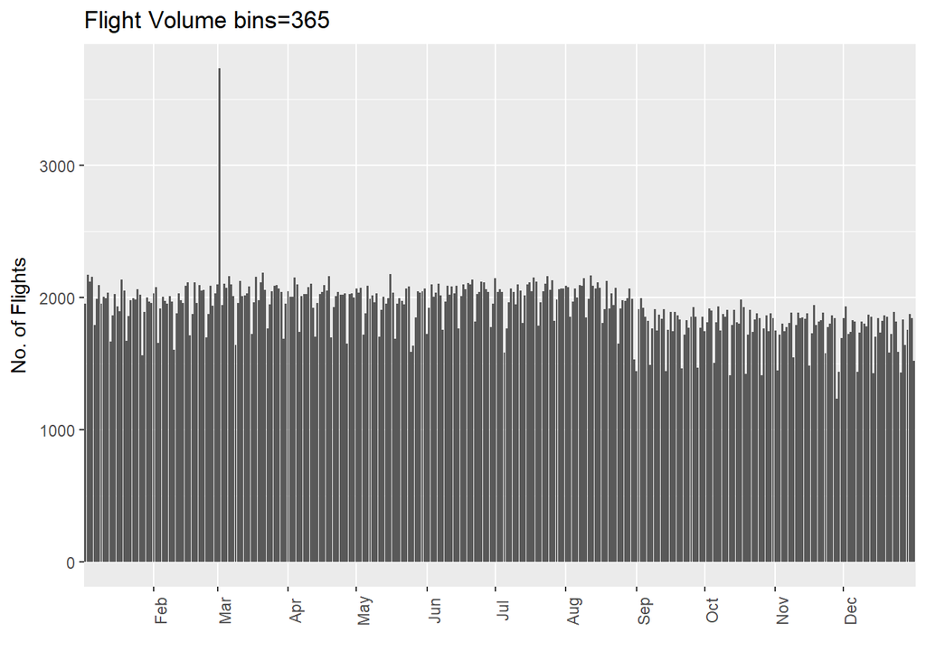

#### **Summary/Analysis:**

The first thing that stands out is the anamolous spike near the left side of the plot. As it turns out this spike is on day 60, which normally corresponds to March 1st, but it turns out that 2008 is a leap year, a fact we overlooked. So the 60th day is actually Feb 29th in this data set. The cumulative array we used to build our graph didn’t account for the additional day.

Let’s adjusting the array and re-plotting the data before continuing.

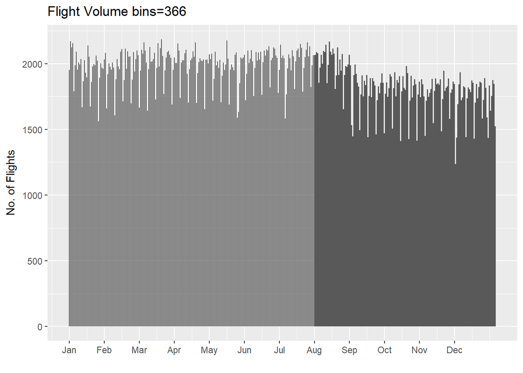

#### **Summary/Analysis:**

Correcting for a leap year, the outlier disappears and we have a better plot to analyze. Again the overall distribution at first glance looks fairly uniform, but a closer looks shows all kinds of patterned variation that look like they might be attributable to days of the week and the beginning or end of a month. While the highest values don’t show extreme variation, there are minima that stand out.

Let’s add plot lines for delay counts.

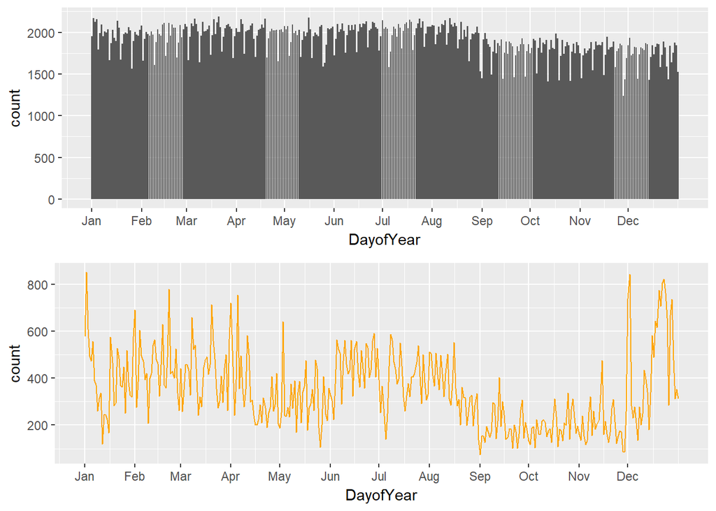

#### **Summary/Analysis:**

Even without using proportional data to control for differences in flight volume the delay counts by day confirms our intuition that delays are seasonal and apparently closely associated with specific holidays. For example the days leading up to Christmas show disproportionately high dealys and the summer months, though not showing the spikes that December does, still show consitently higher delay counts than autumn months. The high variability in delays counts during spring months warrents further investigation.

Let’s look at this from another graphical angle.

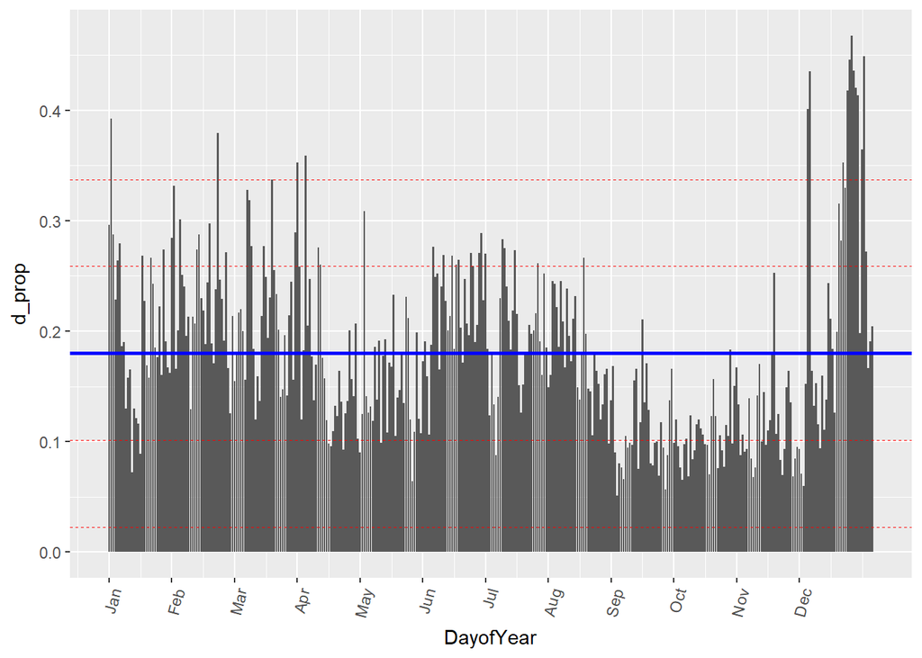

#### **Summary/Analysis:**

The results are unequivocal even before we have conducted inference - there is a clear association between `DayofYear` and `DepDelay`. The results bolster the anecdotal evidence that holidays are particularly fraught with delays but our analysis has at the same time been counterintuitive dispelling the notion that the delays are attributable to increased flight volume.

As a variable for a predictive model this variable likely is highly explanatory of variation in delay proportion. Nonetheless, proportional data conceals total flight counts for each day. Days with low flight volumes but coincidently for this particular data set have a large number of delays would not be reliable preditors outside of this data set. Using `Month` in place of `DayofYear` might be less accurate cut might be more generalizable. Let’s glance at the summary of flight volume by day to aid or decision.

```
##    Min. 1st Qu.  Median    Mean 3rd Qu.    Max.
##    1237    1812    1953    1911    2047    2187
```

Based on the summary stats and the earlier related plots, it’s safe to assume that, because each day has at least 1237 flights, the proportion of delayed flights converges on an actual population proprotion. `DayofYear` will likely be a very strong predictor and have a very high R-squared value.

Now let’s zoom in on the latter part of the year where some of the most pronounced minima are and try to answer the question: What explains the variation across the individual days of the year? What explains some of the extreme minima?

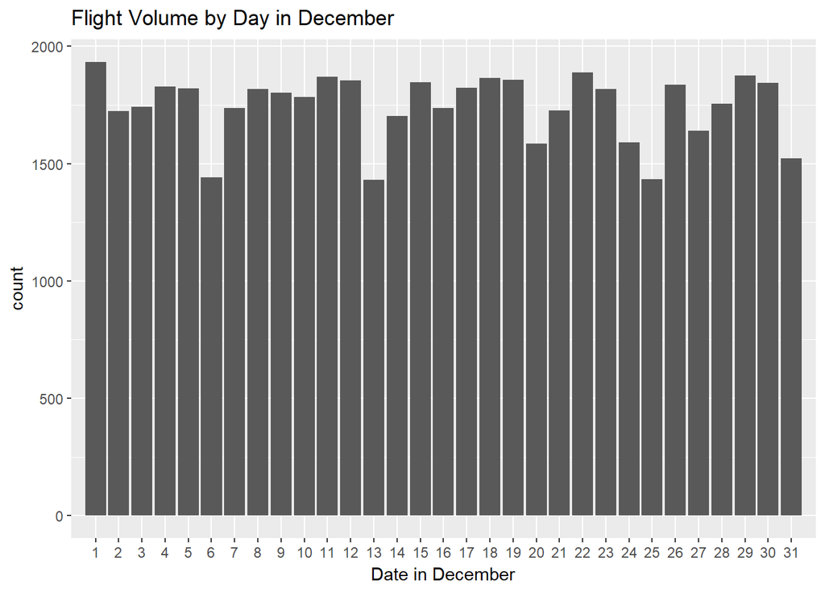

#### **Summary/Analysis:**

Again, there’s a roughly patterned variation in the flight volume. As we’ve found evidence against flight volume being associated with delays, we won’t linger on this plot. Instead, let’s follow the same series of steps we did with `Month` to calculate the proprotion of delayed flights by day.

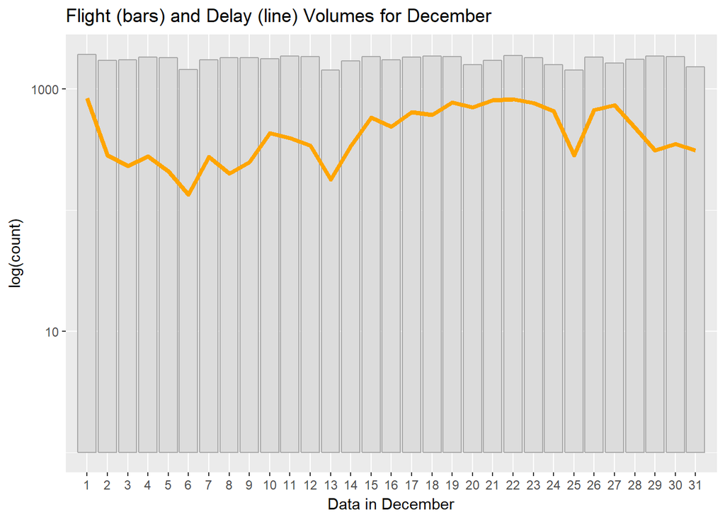

#### **Summary/Analysis:**

Again, while delays associated closely with time stamp factors, flight volume appears to be independent of delays.

Let’s move away from time variable and now look at how airline carriers associate with delays.

#### **Variable:**

`UniqueCarrier`

#### **Intuition/Motivation:**

Most carriers have reputations for either being on-time and dependable or notoriously unreliable. Let’s start by examining the distribution of flights by carrier to see which are the most popular.

```
## # A tibble: 20 x 2
##    UniqueCarrier  count
##           <fctr>  <int>
##  1            9E  26070
##  2            AA  60488
##  3            AQ    781
##  4            AS  14833
##  5            B6  19461
##  6            CO  29756
##  7            DL  45523
##  8            EV  27650
##  9            F9   9519
## 10            FL  26144
## 11            HA   6076
## 12            MQ  48677
## 13            NW  34772
## 14            OH  19678
## 15            OO  56629
## 16            UA  44922
## 17            US  45508
## 18            WN 120026
## 19            XE  37736
## 20            YV  25251
```

```
##    Min. 1st Qu.  Median    Mean 3rd Qu.    Max.
##     781   19624   28703   34975   45512  120026
```

The range of flight volumes is enormous. But what does this say about an airline? Is `UniqueCarrier` indicative of reliability as measured by frequency of delays?

First, we’ll get some additional information about airlines and add it to our data frame. Then we’ll compare the volume of flights across carriers.

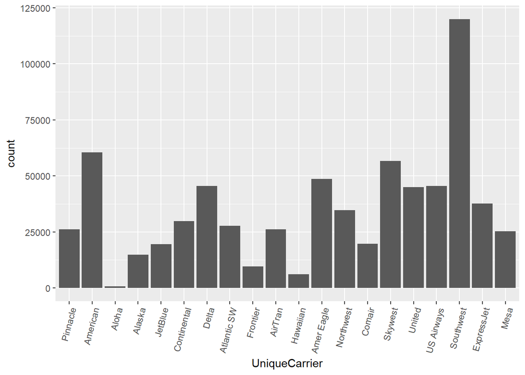

The variation in volume is considerable, so we’ll again use proportional delay data to compensate for this.

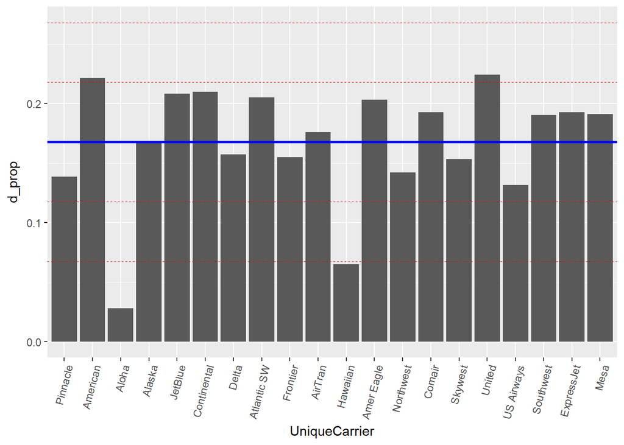

#### **Summary/Analysis:**

The variation is minimal and the delay proportion for only two carriers are statistically significant. Referring to the plot of flight volumes, we can see both of these carriers had very low numbers of flights for 2008. They are also both minor airlines that most travelers either aren’t familiar with or which they only fly occasionally. So they don’t become leverage points in our predictive model and represent only a small portion of our full data set, we’ll eliminate them from the analysis before performing inferential analysis.

```
##
##     AirTran      Alaska  Amer Eagle    American Atlantic SW      Comair
##       26144       14833       48677       60488       27650       19678
## Continental       Delta  ExpressJet    Frontier     JetBlue        Mesa
##       29756       45523       37736        9519       19461       25251
##   Northwest    Pinnacle     Skywest   Southwest      United  US Airways
##       34772       26070       56629      120026       44922       45508
```

With this more robust version of our data set, we can test for a significant association between `UniqueCarrier` and `Delay`, using a chi-square test.

```
## Chi-squared: 0.01456191
```

```
##
## p-value: 6.027554e-15
```

Before moving to another variable let’s look at how our previous examination of the association between `Month` and `Delay` proportion changes when we add the `UniqueCarrier` variable.

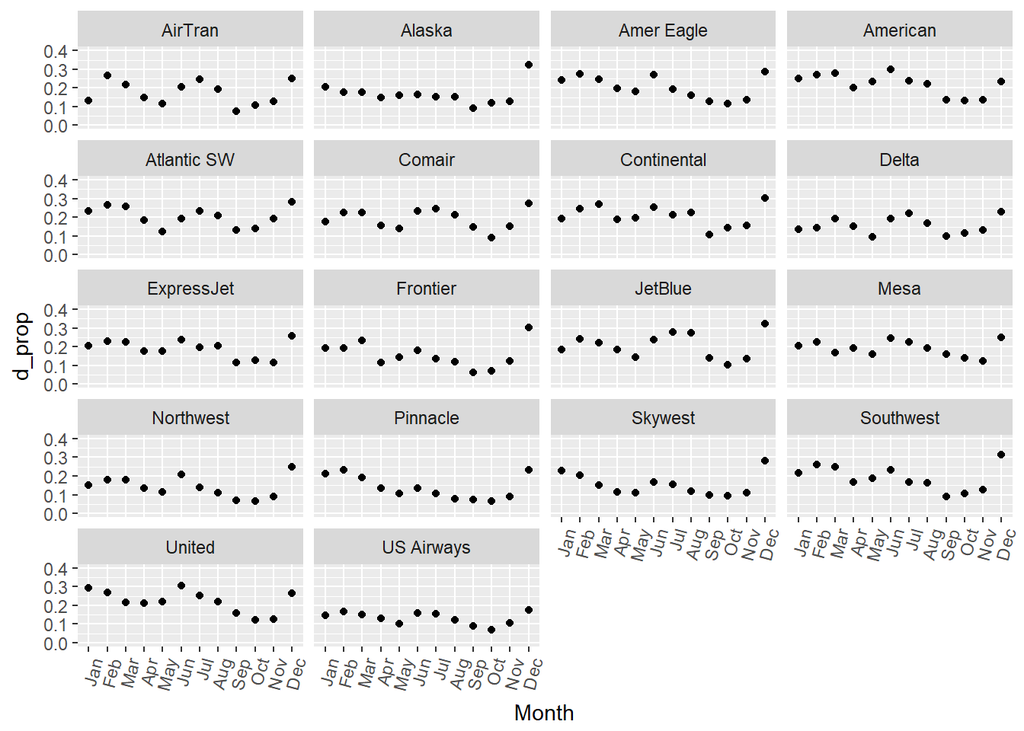

#### **Summary/Analysis:**

The faceted plot reveals an interesting pattern - the proportion of delays by month forms a wave like variation that is consistent across carriers. Recall that it is the same pattern we saw in the bivariate analysis of delays by month with peaks in the early months of the year, in summer and again in December. We saw a roughly similar distribution when we looked at `DayofYear`.

This similarity suggest that the time of year of a flight is more predictive than the carrier. There are some airlines that appear to have lower delay proportions than others (e.g. US Airways vs Continental), but the plot, because it squeezes so many plots into a small space, sacrifices the detail we need to see if their is significant variation across carrier by month.

Let’s try another plotting strategy to see if `CarrierName` explains a significant proportion of the variation in delays proportions beyond what is associated with `Month` .

To do this we’ll split the carriers into three groups by volume of flights. Then we’ll create a summary function to help with plotting means and SE intervals. After which, we’ll plot delay proportions by month of the large volume carriers first.

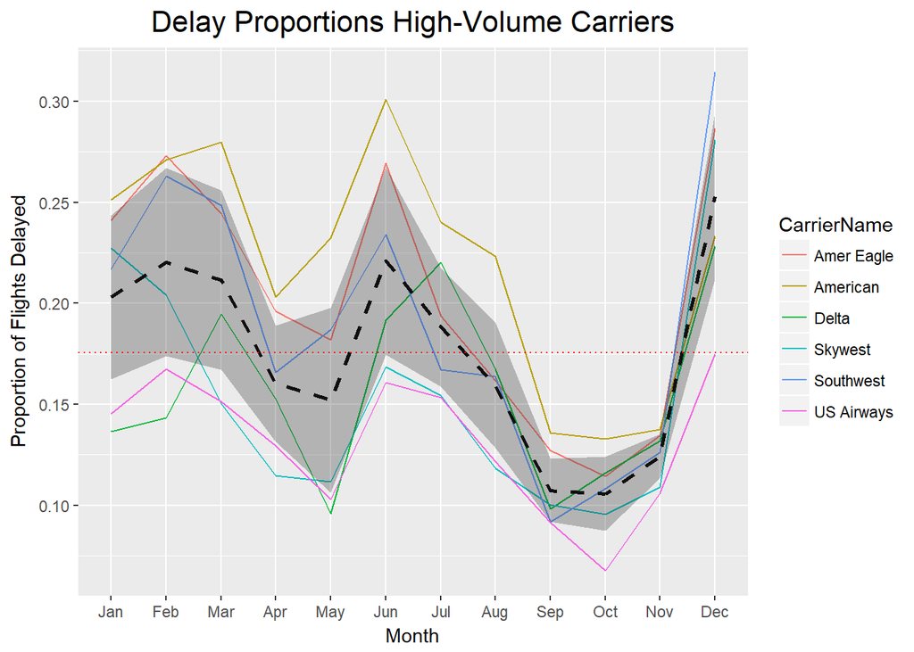

#### **Summary/Analysis:**

There are only a couple large-volume airlines that consistently fall outside a 95% confidence interval for the mean delay proportion. This suggests that `CarrierName` might not be a positive but not strong predictor beyond what is explained by `Month` or `DayofYear`. Let’s first look at medium- and low-volume carriers before we conclude this, though.

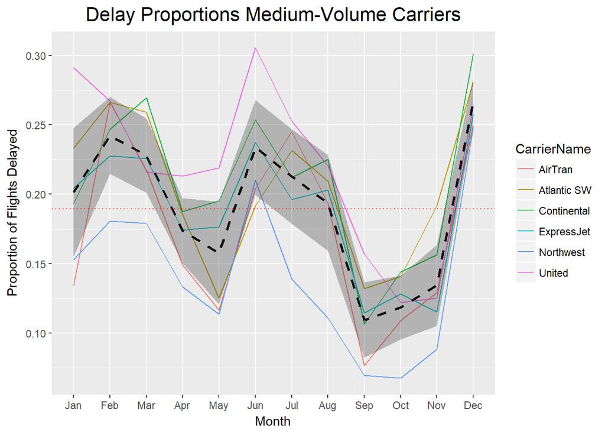

#### **Summary/Analysis:**

Again, the same situation, there are a couple of airlines that consistently have proportions beyond two SE from the mean.

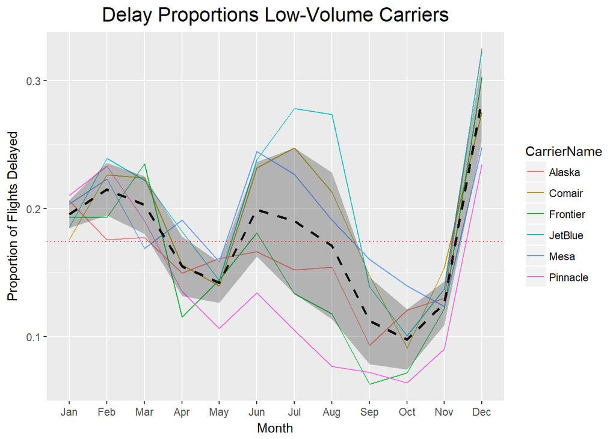

#### **Summary/Analysis:**

It appears there are airlines with consistently high and low values in all three of our groupings. Since the total number of carriers is low it may still be worth including this variable in our predictive model, even though most of the monthly variation for most carriers falls within an expected range.

Next let’s look at the airport flights leave from for an association with `Delay`.

#### **Variable:**

`Origin` - Airport of Departure

#### **Intuition/Motivation:**

I would expect this variable to be highly associated with departure delays because it would be a covariate for other factors like weather and late aircraft. Also, I would expect for the variation in delays by airport to be very wide. There are many potential reasons for this, such as the number of runways, quality of infrastructure and the design of the airport among others.

Judging by the delay factors we investigated I would suspect large airports that serve as tranfer hubs to have the highest delay rate because they would be most suseptable to late aircraft delays.

Let’s start by taking a look at the relative distributions of flight volume by airport.

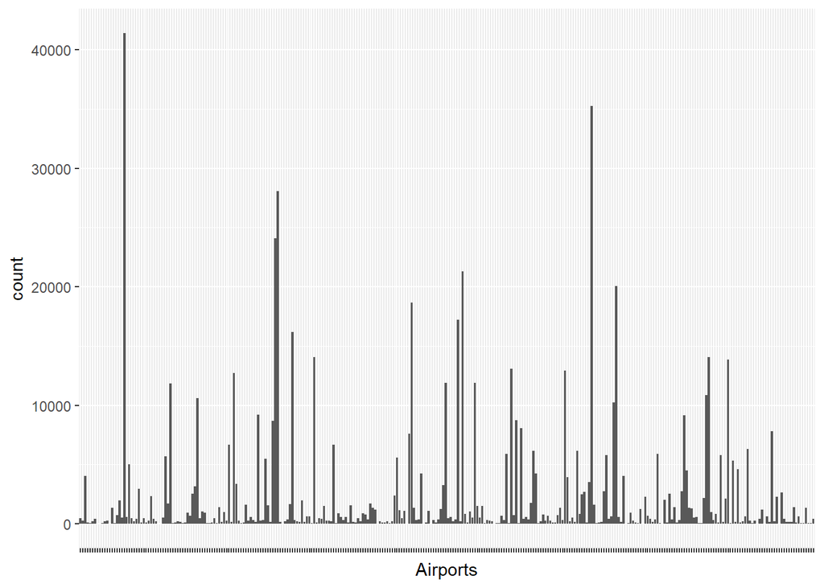

#### **Summary/Analysis:**

The names of the airports have been left off the x-axis because there are simply too many to include them legibly.

Clearly the distribution of flight volume is very wide. Some of the values look like potential outliers, especially those at or near 0, but it’s difficult to distinguish a lot of detail. Let’s narrow the range of our variable. Many of the airports look to have relatively low or even insignificant numbers of flights. Let’s look at the descriptive stats.

```
##
##   ABE   ABI   ABQ   ABY   ACK   ACT   ACV   ACY   ADK   ADQ   AEX   AGS
##   448   254  4040   100    50   207   402    12     9    70   228   241
##   AKN   ALB   ALO   AMA   ANC   ASE   ATL   ATW   AUS   AVL   AVP   AZO
##    11  1318    42   736  1946   523 41408   587  5011   437   219   394
##   BDL   BET   BFL   BGM   BGR   BHM   BIL   BIS   BJI   BLI   BMI   BNA
##  2966    94   444    76   243  2345   433   226     9    10   529  5686
##   BOI   BOS   BPT   BQK   BQN   BRO   BRW   BTM   BTR   BTV   BUF   BUR
##  1680 11830    24    89   179   144    74    83   912   692  2550  3125
##   BWI   BZN   CAE   CAK   CDC   CDV   CEC   CHA   CHO   CHS   CIC   CID
## 10593   448  1048   905    66    61   111   454    72  1404   158   954
##   CLD   CLE   CLL   CLT   CMH   CMI   CMX   COD   COS   CPR   CRP   CRW
##   232  6651   143 12701  3370   248    34   107  1605   263   578   323
##   CSG   CVG   CWA   DAB   DAL   DAY   DBQ   DCA   DEN   DFW   DHN   DLG
##   149  9175   260   296  5453  1551   140  8699 24073 28070   128    10
##   DLH   DRO   DSM   DTW   EGE   EKO   ELM   ELP   ERI   EUG   EVV   EWN
##   208   343  1651 16189   289   179   143  1987   148   606   599    71
##   EWR   EYW   FAI   FAR   FAT   FAY   FCA   FLG   FLL   FLO   FNT   FSD
## 14046    97   455   417  1496   238   252   211  6659    63   866   573
##   FSM   FWA   GCC   GEG   GFK   GGG   GJT   GNV   GPT   GRB   GRK   GRR
##   295   585    99  1553   167    92   461   205   885   777   371  1678
##   GSO   GSP   GST   GTF   GTR   GUC   HDN   HHH   HLN   HNL   HOU   HPN
##  1360  1199    11   222    89    78   221    72   188  2353  5561  1119
##   HRL   HSV   HTS   IAD   IAH   ICT   IDA   ILM   IND   INL   IPL   ISP
##   469  1077    18  7589 18644  1321   313   334  4227     4   104  1089
##   ITH   ITO   IYK   JAC   JAN   JAX   JFK   JNU   KOA   KTN   LAN   LAS
##    14   283   101   373  1218  3235 11902   449   551   219   361 17223
##   LAW   LAX   LBB   LCH   LEX   LFT   LGA   LGB   LIH   LIT   LMT   LNK
##   213 21287   831    89  1025   496 11882  1501   500  1520    56   312
##   LRD   LSE   LWB   LWS   LYH   MAF   MBS   MCI   MCN   MCO   MDT   MDW
##   232   224    18    57    62   681   293  5901    59 13084   732  8743
##   MEI   MEM   MFE   MFR   MGM   MHT   MIA   MKE   MKG   MLB   MLI   MLU
##    72  8059   425   589   370  1767  6166  4262    40   199   794   277
##   MOB   MOD   MOT   MQT   MRY   MSN   MSO   MSP   MSY   MTJ   MYR   OAJ
##   645   239    98    93   734  1346   321 12934  3919   221   493   126
##   OAK   OGG   OKC   OMA   OME   ONT   ORD   ORF   OTH   OTZ   OXR   PBI
##  6147   814  2486  2696   111  3523 35259  1588    58    96   126  2753
##   PDX   PFN   PHF   PHL   PHX   PIA   PIH   PIR   PIT   PLN   PMD   PNS
##  5779   410   642 10212 20048   558   157     0  4030    22    71   932
##   PSC   PSE   PSG   PSP   PUB   PVD   PWM   RAP   RDD   RDM   RDU   RFD
##   237    80    66  1233     1  2268   670   412   173   379  5900    26
##   RHI   RIC   RKS   RNO   ROA   ROC   ROW   RST   RSW   SAN   SAT   SAV
##    22  2004    82  2511   359  1379   101   325  2715  9127  4519  1349
##   SBA   SBN   SBP   SCC   SCE   SDF   SEA   SFO   SGF   SGU   SHV   SIT
##  1301   533   565    68    67  2194 10833 14060  1000   321   799   109
##   SJC   SJT   SJU   SLC   SLE   SMF   SMX   SNA   SPI   SPS   SRQ   STL
##  5777   134  2142 13858    58  5302   163  4612   112   187   640  6296
##   STT   STX   SUN   SUX   SWF   SYR   TEX   TLH   TOL   TPA   TRI   TUL
##   277    38   280     7   403  1191    12   622   144  7828   198  2270
##   TUP   TUS   TVC   TWF   TXK   TYR   TYS   VLD   VPS   WRG   WYS   XNA
##     2  2653   392   161   135   167  1390    96   635    53    24  1364
##   YAK   YKM   YUM
##    61    41   411
```

```
##    Min. 1st Qu.  Median    Mean 3rd Qu.    Max.
##     1.0   134.2   414.5  2293.5  1579.2 41408.0
```

```
## # A tibble: 1 x 2
##   Origin volume
##   <fctr>  <int>
## 1    ATL  41408
```

The airport code ATL corresponds to Atlanta Hartfield-Jackson airport. According to the airport [website](http://www.atl.com/about-atl/atl-factsheet/), the airport sees about 2,500 arrivals and departures a day. If we assume that half of those are departures and multiple by 365 we get 456250 a number that makes the 2008 departure volume look like anything but an outlier. Backing this up is the [Bureau of Tansportation Statistics](https://www.rita.dot.gov/bts/sites/default/files/rita_archives/bts_press_releases/2009/bts019_09/html/bts019_09.html) (the source for our data set) which lists ATL as the busiest airport in the US.

To aid us in our focused exploration of airports in the flight data, let’s call upon some additional data sources that make some of the details on each airport included in `flights` more accessible.

```
##  [1] "ident"        "type"         "name"         "lat"
##  [5] "long"         "elevation_ft" "continent"    "iso_country"
##  [9] "iso_region"   "municipality" "gps_code"     "iata_code"
## [13] "local_code"
```

Merging the airport data to our flights data set not only makes it easier to correlate the three-letter IATA abbreviations used in our data set and commonly seen on airline tickets, but adds several powerful variables to our data. The first new variable we’ll harness is `type`. Let’s look at the levels of this categorical variable to see how it can help us.

```
##
##    balloonport         closed       heliport  large_airport medium_airport
##              0          10833              0         628373          50286
##  seaplane_base  small_airport
##              0           1541
```

The variable divides our departure airport data neatly into groups based on size. At the same time this is complicated by over 10833 observations from a closed airport. This probably arised because our flight data is from 2008 and the airport data we aggregrated is newer. Let’s investigate the closed airport observations before deciding how to handle them.

```
##        Origin UniqueCarrier CarrierName Year Month DayofMonth DayOfWeek
## 596035    SEA            AS      Alaska 2008     9         26         5
## 596037    SEA            US  US Airways 2008     2          4         1
## 596039    SEA            AS      Alaska 2008     6          5         4
## 596041    SEA            NW   Northwest 2008    11          6         4
## 596043    SEA            AS      Alaska 2008     6         20         5
##        DepTime CRSDepTime ArrTime CRSArrTime FlightNum TailNum
## 596035    1500       1500    1749       1744       470  N755AS
## 596037     754        800    1007       1027       293  N315AW
## 596039    1058       1100    1319       1339       462  N589AS
## 596041     720        650    1232       1206       804  N595NW
## 596043     726        730     926        947       340  N975AS
##        ActualElapsedTime CRSElapsedTime AirTime ArrDelay DepDelay Dest
## 596035               169            164     135        5        0  LAX
## 596037               133            147     107      -20       -6  LAS
```

[output cut: 27 more lines]

One of the closed airport is listed as “seattle airport”. There isn’t actually an airport by that name, and strangley it has the same IATA abbreviation, “SEA”, as Seattle-Tacoma Airport one of the busiest airports in the country. Let’s use the IATA code to see if Seattle-Tacoma is accounted for in the data set.

```
##        Origin UniqueCarrier CarrierName Year Month DayofMonth DayOfWeek
## 596034    SEA            AS      Alaska 2008     9         26         5
## 596035    SEA            AS      Alaska 2008     9         26         5
## 596036    SEA            US  US Airways 2008     2          4         1
## 596037    SEA            US  US Airways 2008     2          4         1
## 596038    SEA            AS      Alaska 2008     6          5         4
## 596039    SEA            AS      Alaska 2008     6          5         4
##        DepTime CRSDepTime ArrTime CRSArrTime FlightNum TailNum
## 596034    1500       1500    1749       1744       470  N755AS
## 596035    1500       1500    1749       1744       470  N755AS
## 596036     754        800    1007       1027       293  N315AW
## 596037     754        800    1007       1027       293  N315AW
## 596038    1058       1100    1319       1339       462  N589AS
## 596039    1058       1100    1319       1339       462  N589AS
##        ActualElapsedTime CRSElapsedTime AirTime ArrDelay DepDelay Dest
```

[output cut: 41 more lines]

The problem with the closed airport count derives from the entries for Seattle-Tacoma being duplicated using an airport name that was classified as closed. Let’s remove all the flight records for “seattle airport”.

Let’s look again at the table of counts for each type of airport.

```
##
##    balloonport         closed       heliport  large_airport medium_airport
##              0              0              0         628373          50286
##  seaplane_base  small_airport
##              0           1541
```

We’re fortunate, the SEA anomoly accounted for all of the closed airport observations. This leaves our data neatly divided into three groups by airport size. We can use this to break up our previous plot into smaller, more manageable plots. This time instead of plotting flight volume we’ll go directly to working with delay proportions.

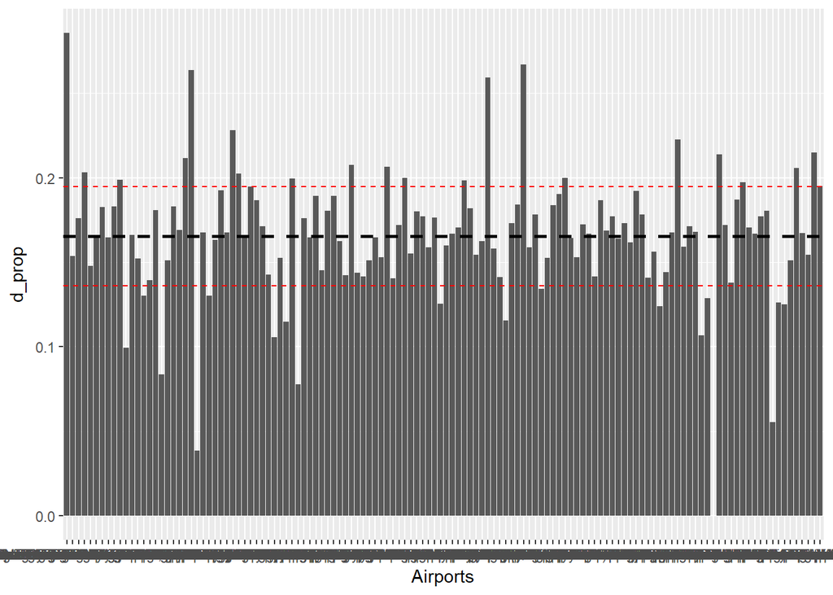

[output not shown]

#### **Summary/Analysis:**

Here we have decided to leave the airport names off the x-axis for reasons of legibility.

```
##  [1] Abraham Lincoln Capital Airport
##  [2] Augusta Regional At Bush Field
##  [3] Bill & Hillary Clinton National Airport/Adams Field
##  [4] Chicago Midway International Airport
##  [5] Chicago O'Hare International Airport
##  [6] Dallas Fort Worth International Airport
##  [7] Dallas Love Field
##  [8] Denver International Airport
##  [9] Fort Lauderdale Hollywood International Airport
## [10] Hartsfield Jackson Atlanta International Airport
## [11] John F Kennedy International Airport
## [12] La Guardia Airport
## [13] McCarran International Airport
## [14] Miami International Airport
## [15] Newark Liberty International Airport
## [16] Philadelphia International Airport
## [17] San Francisco International Airport
## [18] South Bend Regional Airport
## [19] Syracuse Hancock International Airport
## [20] Washington Dulles International Airport
## [21] William P Hobby Airport
## [22] Yeager Airport
## 43628 Levels: 'S Gravenvoeren heliport ... Zyryanka Airport
```

Most of the airports that have statistically significant delay proportions are indeed recognizable as large transfer hubs.

Let’s also look at medium and small airports. I’d suspect there to be fewer proportions significantly greater than the mean since these airports would see fewer transfers and thus fewer late aircraft delays.

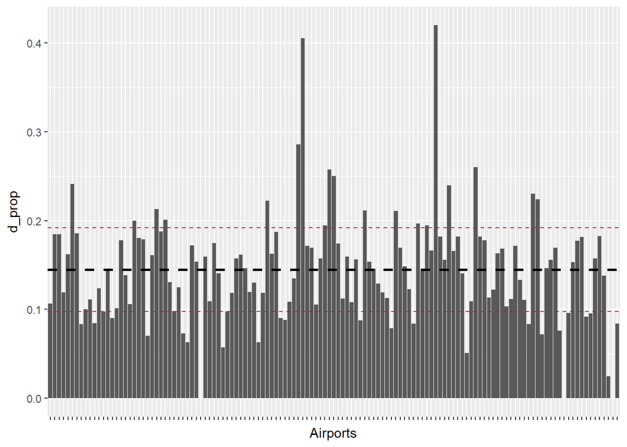

#### **Summary/Analysis:**

Again the names have been left off to make the plot legible.

Medium airports have a lower overall mean delay proportion than large airports but there are also in this set several example of airports with high delay rates. Let’s see if any stand out as recognizable transfer hubs.

```
##  [1] Arcata Airport
##  [2] Central Wisconsin Airport
##  [3] Daytona Beach International Airport
##  [4] Eagle County Regional Airport
##  [5] Greenbrier Valley Airport
##  [6] Ithaca Tompkins Regional Airport
##  [7] Jack Mc Namara Field Airport
##  [8] Key Field
##  [9] Key West International Airport
## [10] Klamath Falls Airport
## [11] Lincoln Airport
## [12] Melbourne International Airport
## [13] Modesto City Co-Harry Sham Field
## [14] Montrose Regional Airport
## [15] Nantucket Memorial Airport
## [16] Palmdale Regional/USAF Plant 42 Airport
## [17] Redding Municipal Airport
## [18] Southwest Georgia Regional Airport
## [19] Southwest Oregon Regional Airport
## 43628 Levels: 'S Gravenvoeren heliport ... Zyryanka Airport
```

None of these standout as airports that as transfer points would expect high late aircraft delay rates.

Now for small airports.

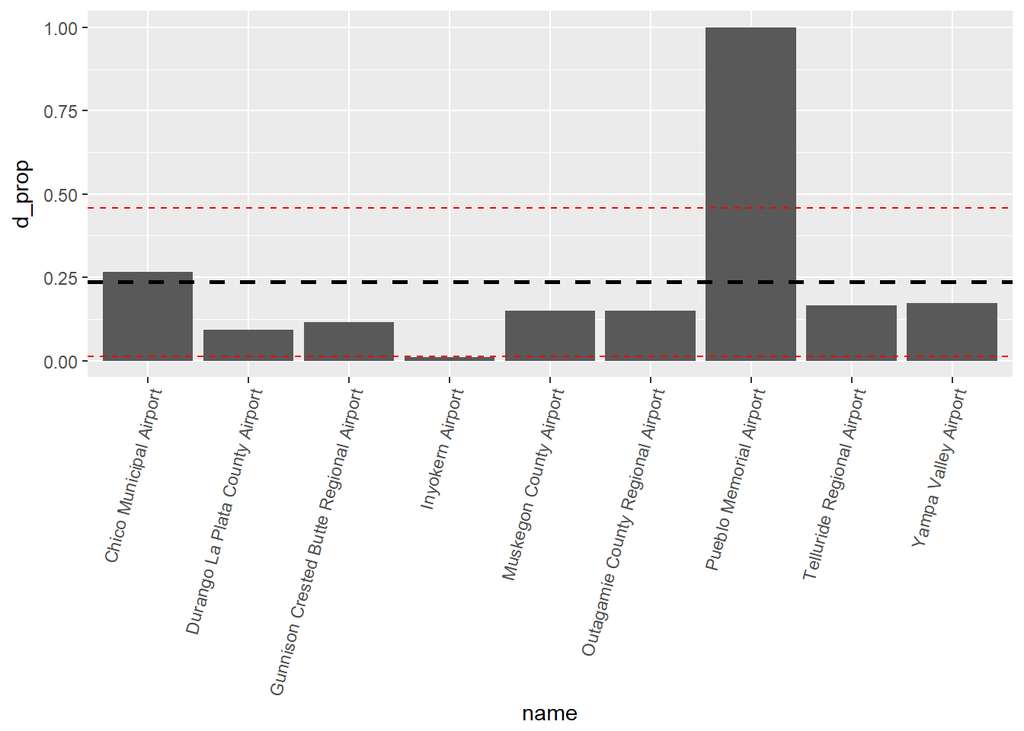

#### **Summary/Analysis:**

In all three groups there are airports well outside of the expected proportion of delays based on the overall mean. Going back to our motivation for exploring this variable in the first place, let’s dig deeper and try and see why some airports might have proportions so far away from the mean. What comes to mind first is weather. We of course have `WeatherDelay` as an obvious measure but this is post-de-facto record of the delay and the aim is probabilistic prediction. Airports are a likely covariate of weather so let’s look for sign that that might be the case.

Elevation and latitude are good candidates as indicators of delay causing inclement weather.

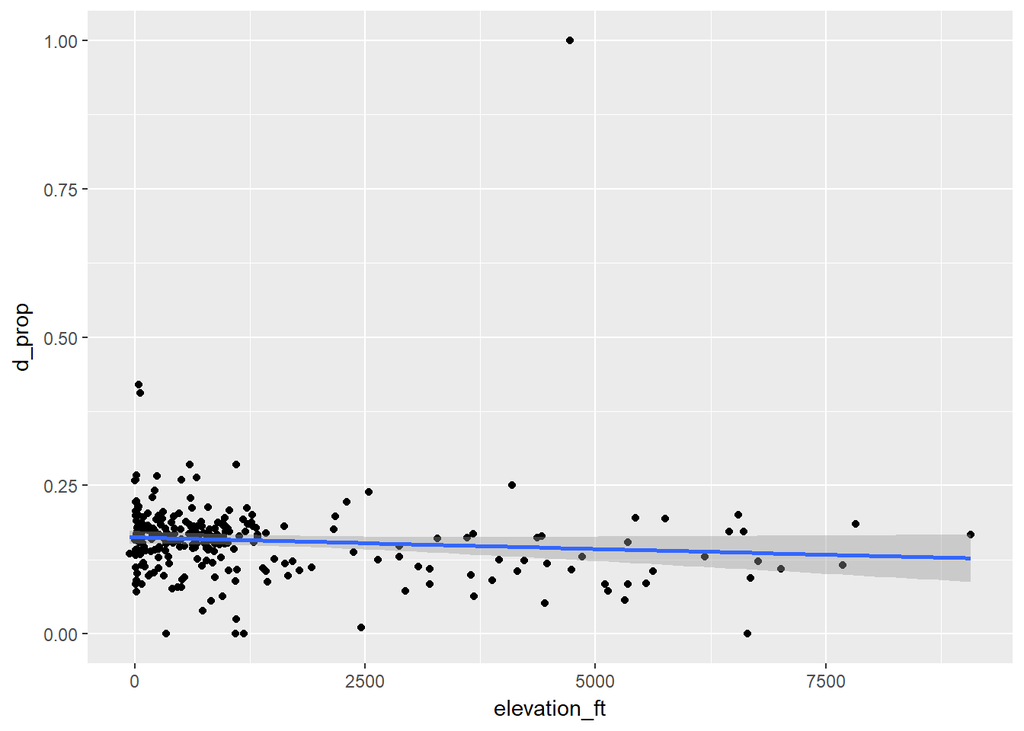

```
##
## Call:
## lm(formula = elevation_ft ~ d_prop, data = flights.orn_elev)
##
## Residuals:
##     Min      1Q  Median      3Q     Max
## -1479.3 -1110.2  -627.0     6.6  7792.8
##
## Coefficients:
##             Estimate Std. Error t value Pr(>|t|)
## (Intercept)   1658.2      258.8   6.408 6.75e-10 ***
## d_prop       -2285.9     1483.4  -1.541    0.125
## ---
## Signif. codes:  0 '***' 0.001 '**' 0.01 '*' 0.05 '.' 0.1 ' ' 1
##
## Residual standard error: 1799 on 264 degrees of freedom
## Multiple R-squared:  0.008915,   Adjusted R-squared:  0.005161
## F-statistic: 2.375 on 1 and 264 DF,  p-value: 0.1245
```

#### **Summary/Analysis:**

There’s no statistically significant relationship between these variables.

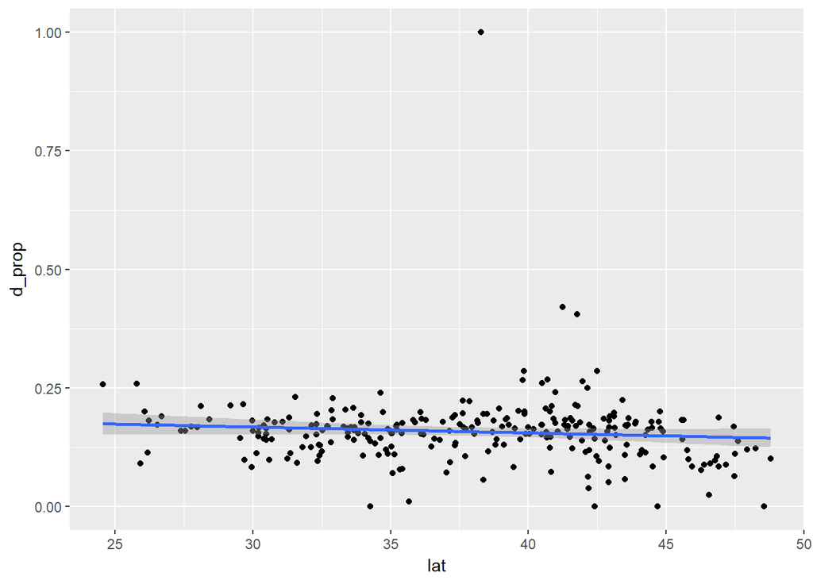

```
##
## Call:
## lm(formula = d_prop ~ lat, data = flights.orn_lat)
##
## Residuals:
##      Min       1Q   Median       3Q      Max
## -0.16235 -0.03099  0.00002  0.02340  0.84267
##
## Coefficients:
##               Estimate Std. Error t value Pr(>|t|)
## (Intercept)  0.2051602  0.0314327   6.527 3.42e-10 ***
## lat         -0.0012493  0.0008205  -1.523    0.129
## ---
## Signif. codes:  0 '***' 0.001 '**' 0.01 '*' 0.05 '.' 0.1 ' ' 1
##
## Residual standard error: 0.07432 on 264 degrees of freedom
## Multiple R-squared:  0.008704,   Adjusted R-squared:  0.004949
## F-statistic: 2.318 on 1 and 264 DF,  p-value: 0.1291
```

#### **Summary/Analysis:**

Likewise here, the relationship between latitude and delay proportion is not statistically significant.

What stands out in both of the plots is the single observation at the uppermost range of the panel with a proportion of delays at 1.0, which would mean that 100% of the flights out of that airport were delayed in 2008. This seems unlikely and deserves further investigation.

```
## # A tibble: 1 x 3
## # Groups:   Origin [1]
##   Origin     lat d_prop
##   <fctr>   <dbl>  <dbl>
## 1    PUB 38.2891      1
```

The IATA code corresponds to Pueblo Memorial Airport an example belonging to our small airports classification. Let’s look at all the flights out of the airport to see if in fact they were all delayed.

```
##        Origin UniqueCarrier CarrierName Year Month DayofMonth DayOfWeek
## 557119    PUB            XE  ExpressJet 2008     7          8         2
##        DepTime CRSDepTime ArrTime CRSArrTime FlightNum TailNum
## 557119    1740       1655    1814       1704       104  N14174
##        ActualElapsedTime CRSElapsedTime AirTime ArrDelay DepDelay Dest
## 557119                34              9      11       70       45  COS
##        Distance TaxiIn TaxiOut Cancelled CancellationCode Diverted
## 557119       37      5      18         0                         0
##        CarrierDelay WeatherDelay NASDelay SecurityDelay LateAircraftDelay
## 557119            0           45       25             0                 0
##        Month_Name DayofYear Delay          type                    name
## 557119       July       190     1 small_airport Pueblo Memorial Airport
##            lat     long elevation_ft
## 557119 38.2891 -104.497         4726
```

There is record of only one flight (which was delayed explaining the proportion in the plots), yet the Federal Aviation Administration (FAA) recorded 4,345 emplanements, or boarding passengers, in 2008, far more than fit on a single flight. Why then the discrepency between our data and the FAA records. Keep in mind that PUB is a small airport with low flight volume and that we chose to randomly sample from the full 2008 data set. In all likelihood, the small number of flights out of PUB and our small sample proportion resulted in a single observation from this airport, which happened to be delayed. There are a couple solutions: we could eliminate the observation with some confidence that it wouldn’t affect our results significantly since we our focusing more on larger airports, or deliberately take more samples from the full data set from this particular airport.

So far we’ve looked at how flight origin labels in a graphical context that highlights flight volume and proportions of total flights delayed. But the factor is essentially geographical data and plotting them in that context while still coding for flight volume and other variables might lend them the space necessary for otherwise overlooked patterns to standout.

Let’s look at the airports plotted on basemap.

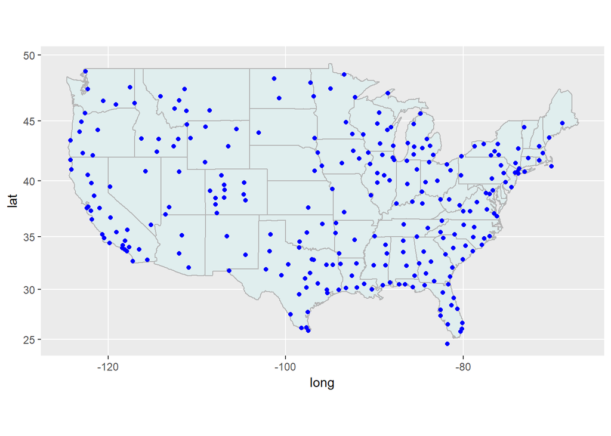

Let’s add more dimension to our plot by including data for the variable `type` which after we cleaned the data ended up encoding the size of the airport.

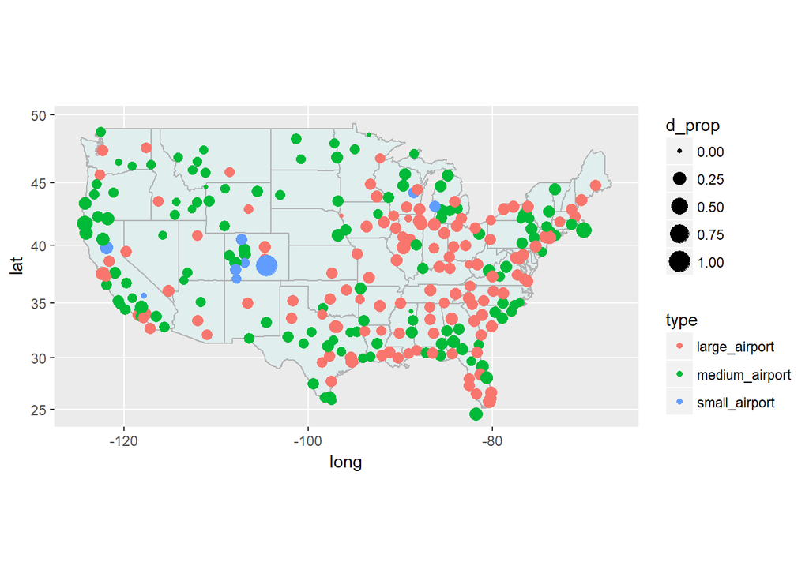

#### **Summary/Analysis:**

It’s difficult to detect any meaningful pattern in the geographical plot. It looks like there might be some contrast in delay proportion regionally for example between the Mountain West and the Northeast. Coastal airports seem to have higher delay rates, too.

```
## # A tibble: 3,024 x 6
## # Groups:   Month, Origin, lat, long [3,024]
##    Month Origin     lat     long           type     d_prop
##    <int> <fctr>   <dbl>    <dbl>         <fctr>      <dbl>
##  1     4    ABE 40.6521 -75.4408 medium_airport 0.05882353
##  2     7    ABE 40.6521 -75.4408 medium_airport 0.09523810
##  3     9    ABE 40.6521 -75.4408 medium_airport 0.10256410
##  4    10    ABE 40.6521 -75.4408 medium_airport 0.11111111
##  5     8    ABE 40.6521 -75.4408 medium_airport 0.11904762
##  6     5    ABE 40.6521 -75.4408 medium_airport 0.12903226
##  7     2    ABE 40.6521 -75.4408 medium_airport 0.15384615
##  8     3    ABE 40.6521 -75.4408 medium_airport 0.15625000
##  9     1    ABE 40.6521 -75.4408 medium_airport 0.18421053
## 10     6    ABE 40.6521 -75.4408 medium_airport 0.24324324
## # ... with 3,014 more rows
```

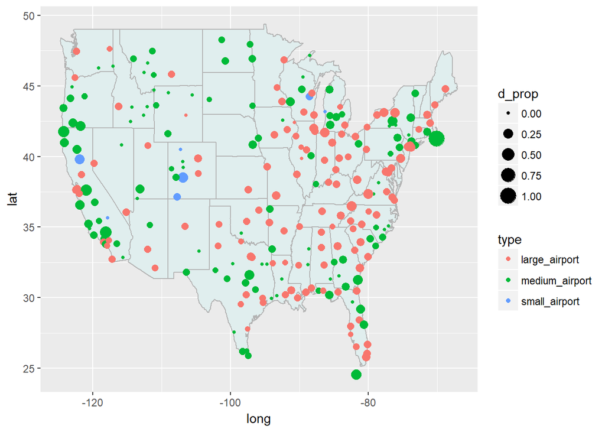

```
##    Min. 1st Qu.  Median    Mean 3rd Qu.    Max.
## 0.00000 0.04348 0.08696 0.09325 0.11392 1.00000
```

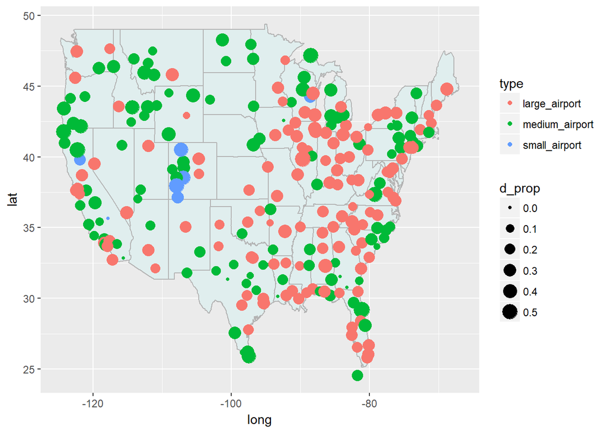

```
##    Min. 1st Qu.  Median    Mean 3rd Qu.    Max.
##  0.0000  0.1877  0.2448  0.2427  0.2941  0.6000
```

#### **Summary/Analysis:**

The two plots show strong variation between the two months but consistently over the geographic extent of the maps, suggesting that delays are not closely associated to region.

## Predictive Model:

Having examined the dimensions and distributions of the variables most intuitively relevant to our guiding questions, we gained a better sense of our data while at the same time removing outliers, generating new variables, and appropriately subsetting our data. We then moved to examining the relationship between the variables we’ve selected and our guiding question on what’s behind flight delays.

Next, we’ll put our insights to work in exploring the predictive power of the variables we’ve explored. We’ll look at two of the variables to see what proportion of the variance of `Delay` they explain. Two of the variables, `DayofYear` and `Origin` involve a large number of levels and thus coefficients and will be left out of this part of the investigation.

```
##
## Call:
## lm(formula = Delay ~ Month_Name, data = flights)
##
## Residuals:
##     Min      1Q  Median      3Q     Max
## -0.2676 -0.2192 -0.1659 -0.1083  0.8917
##
## Coefficients:
##                      Estimate Std. Error t value Pr(>|t|)
## (Intercept)          0.165880   0.001593 104.151  < 2e-16 ***
## Month_NameAugust     0.008181   0.002243   3.647 0.000265 ***
## Month_NameDecember   0.101722   0.002312  44.001  < 2e-16 ***
## Month_NameFebruary   0.067256   0.002284  29.451  < 2e-16 ***
## Month_NameJanuary    0.041209   0.002246  18.352  < 2e-16 ***
## Month_NameJuly       0.030071   0.002230  13.482  < 2e-16 ***
## Month_NameJune       0.061401   0.002246  27.334  < 2e-16 ***
## Month_NameMarch      0.053356   0.002233  23.897  < 2e-16 ***
## Month_NameMay       -0.006480   0.002247  -2.883 0.003935 **
## Month_NameNovember  -0.038981   0.002332 -16.718  < 2e-16 ***
## Month_NameOctober   -0.057599   0.002296 -25.091  < 2e-16 ***
## Month_NameSeptember -0.056272   0.002314 -24.314  < 2e-16 ***
## ---
## Signif. codes:  0 '***' 0.001 '**' 0.01 '*' 0.05 '.' 0.1 ' ' 1
##
## Residual standard error: 0.3844 on 680188 degrees of freedom
## Multiple R-squared:  0.01522,    Adjusted R-squared:  0.0152
## F-statistic: 955.4 on 11 and 680188 DF,  p-value: < 2.2e-16
```

The coefficients from the model accord with what we found previously for this model. The month of December has the largest coefficient meaning it has a strong influence on the probability of a delay relative to other months. Suprisingly, though, this variable explains very little of the overall variation in `Delay`, only around 2%, in fact.

Let’s look at a regression model with the airline carriers as the explanatory variable.

```
##
## Call:
## lm(formula = Delay ~ CarrierName, data = flights)
##
## Residuals:
##     Min      1Q  Median      3Q     Max
## -0.2265 -0.2030 -0.1904 -0.1388  0.8687
##
## Coefficients:
##                         Estimate Std. Error t value Pr(>|t|)
## (Intercept)             0.176057   0.002394  73.550  < 2e-16 ***
## CarrierNameAlaska      -0.019547   0.004368  -4.475 7.64e-06 ***
## CarrierNameAmer Eagle   0.026952   0.002967   9.085  < 2e-16 ***
## CarrierNameAmerican     0.045914   0.002875  15.973  < 2e-16 ***
## CarrierNameAtlantic SW  0.029297   0.003338   8.777  < 2e-16 ***
## CarrierNameComair       0.016573   0.003649   4.542 5.57e-06 ***
## CarrierNameContinental  0.034065   0.003291  10.352  < 2e-16 ***
## CarrierNameDelta       -0.018264   0.003008  -6.072 1.26e-09 ***
## CarrierNameExpressJet   0.016677   0.003112   5.359 8.36e-08 ***
## CarrierNameFrontier    -0.021175   0.004629  -4.574 4.78e-06 ***
## CarrierNameJetBlue      0.033950   0.003688   9.205  < 2e-16 ***
## CarrierNameMesa         0.023018   0.003508   6.562 5.31e-11 ***
## CarrierNameNorthwest   -0.033117   0.003174 -10.433  < 2e-16 ***
## CarrierNamePinnacle    -0.037270   0.003386 -11.007  < 2e-16 ***
## CarrierNameSkywest     -0.021982   0.002898  -7.584 3.35e-14 ***
## CarrierNameSouthwest    0.014327   0.002641   5.425 5.78e-08 ***
## CarrierNameUnited       0.050480   0.003021  16.709  < 2e-16 ***
## CarrierNameUS Airways  -0.044798   0.003007 -14.897  < 2e-16 ***
## ---
## Signif. codes:  0 '***' 0.001 '**' 0.01 '*' 0.05 '.' 0.1 ' ' 1
##
## Residual standard error: 0.3862 on 680182 degrees of freedom
## Multiple R-squared:  0.005654,   Adjusted R-squared:  0.005629
## F-statistic: 227.5 on 17 and 680182 DF,  p-value: < 2.2e-16
```

Here likewise we could have predicted the distribution of coefficients from our earlier exploration. The airline carriers that had statistically significant delay proportions in our earlier graphs have the steepest coefficients in the regression model. Still, the variable explains only a minute proportion of the variation in `Delay`.

## Final Plots

#### Plot 1:

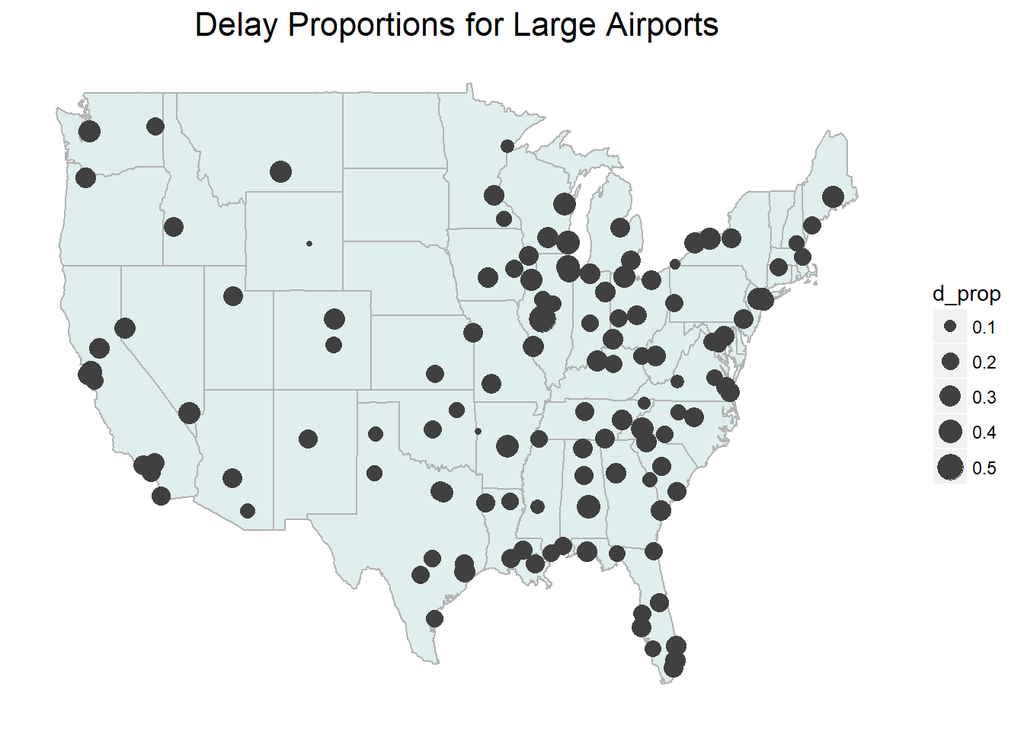

**Description:**

The plot shows the proportion of departure delays at large airports with plot size. The plot clearly shows that while there are a handful of airports with noticeably smaller delay proportions, there is no clear geographic pattern in variance, for example by region or latitude. This reinforces our earlier findings that incredibly weather is not a strong correlate with delays.

Let’s look at the correlative factors for the three geographic measures we have for airports in our data set.

```
## AIC =  639560.1
```

```
##
## McFadden R2 =  0.0007826137
```

Both the AIC and the McFadden R-squared (an logistic analog of R-squared used in linear regression) show that the model of `Delay` as a function of our three geographic variables yields a poor model. Both the plot and the statistics show that geography, counterintuitively, is not a good predictor or delays.

#### Plot 2:

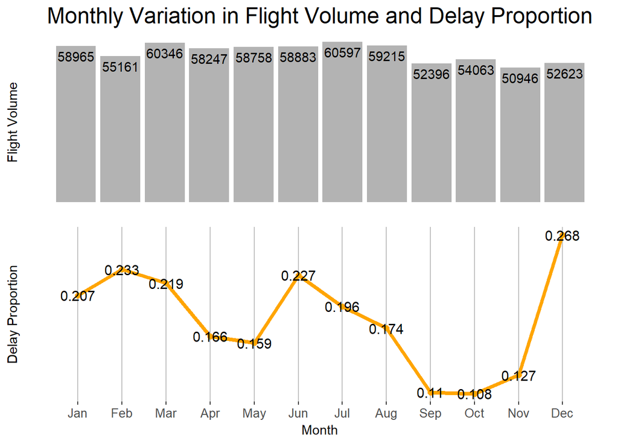

**Description:**

The plot shows the near-uniform distribution of flight volumes over the proportion of flights delayed, both by month. The plot clearly shows that there is no positive association between delays and flight volume. At the same time a multimodal distinct wave-like distribution can be seen across all delay types plotted by month. This suggests that where `Month` and flight volume were not correlated, `Month` and have a strong association with `Delay`.

### Plot 3:

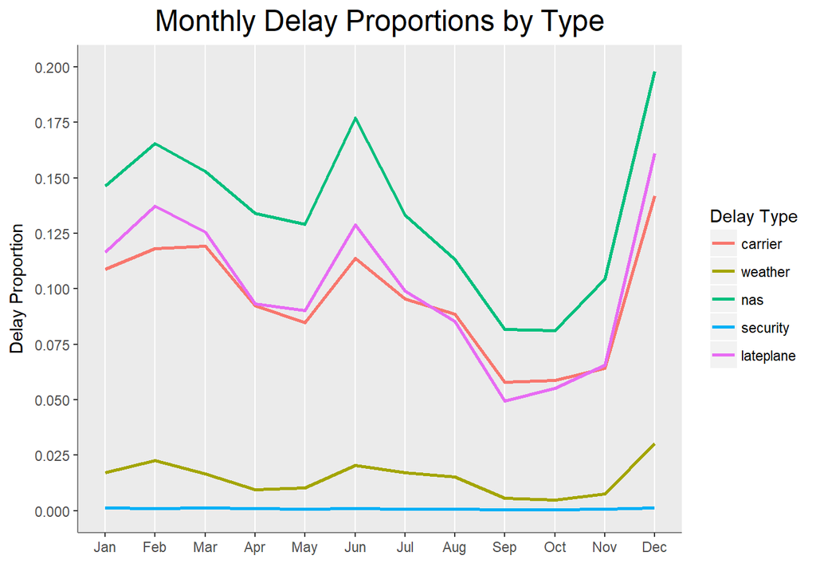

**Description:**

This plot shows the proportion of delays by month for each of the five delay types recorded in the data set. The proportions all are congruent showing the same multimodal distribution that we saw in Plot #2, suggesting a common explanation or cause behind them that is closely associated to `Month` or seasonality. We eleminated flight volume as the lurking variable behind this trend, but passenger volume still needs to be explored. The plot also reiterates the surprisingly low proportion of delays,irregardless of `Month`, that are attributable to weather.

## Reflection

The data set we chose was large enough that we had to subset it to be able to work with it efficiently. Our analysis required that we consult complementary data sources and aggregate into the original data several additional variables. Most of the variables we worked with as explanatory on the response variable `Delay`.

The trends that we suspected going into the investigation, that delays are associated to seasonal and airline variables, for example, were confirmed. At the same time, we discovered that the reasons for these relationships were not what we had intuited, for instance weather and flight volume did not in the end show a clear relationship to flight delays, at least not directly. We discovered an overarching pattern across most of the variables that we examined in which there was a common variation in delay proportion across the months of the year. From this we extrapolated that the variable `Month_Name` would be strongly predictive of `Delay`, however, this explanatory variable and the others we explored while statistically significant, each explained less than 10% of the variation in `Delay`.

Because the EDA did not yield a closely associated explanatory variable or group of variables for `Delay`, further investigation is warrented. Some directions that might take include aggregating average weather patterns by day of the year and airport, creating a quantative variable to measure the effect of arrival delays on departure delays, and gathering data on passenger volume instead of assuming it to be constant.